# Toddler Uncertainty Monitoring

Emily

2017-01-24

Data analysis of toddler uncertainty monitoring study.

# 1 Data preprocessing

Preliminaries.

Read in trial info, demographics, and word familiarity.

```r
demo <- read.csv("demographics.csv")
trial_info <- read.csv("conditions.csv", header = TRUE)
trial_info$trial <- as.character(trial_info$trial)

word_fam_key <- read.csv("word_fam_key.csv")
word_fam_key$trial <- as.character(word_fam_key$trial)

word_fam <- read.csv("word_familiarity.csv") %>%
  tidyr::gather("target", "familiarity", 2:41)

response_key <- read.csv("response_key.csv")
response_key$trial <- as.character(response_key$trial)
```

Read in TS data file.

```r
d.raw_ts <- read.table("AllSubs_TS.txt", header = TRUE)
```

Make TS data tidy.

```r
d_acc_ts<- d.raw_ts %>%
  select(Subject_ID, acc1, acc2, acc3, acc4, acc5, acc6, acc7, acc8, acc9, acc10, acc11, acc12, acc13, acc14, acc15, acc16, acc17, acc18, acc19, acc20)%>%
  gather(trial, acc, acc1:acc20)

d_rt <- d.raw_ts %>%
  select(Subject_ID, RT1, RT2, RT3, RT4, RT5, RT6, RT7, RT8, RT9, RT10, RT11, RT12, RT13, RT14, RT15, RT16, RT17, RT18, RT19, RT20) %>%
  gather(trial, RT, RT1:RT20)

d_acc_ts$trial <-str_replace(d_acc_ts$trial, "acc","")
d_rt$trial <- str_replace(d_rt$trial, "RT","")

d_ts <- d_acc_ts %>%
  left_join(d_rt) %>%
  mutate(ID = Subject_ID) %>%
  select(ID, RT, acc, trial)

d_ts$acc[d_ts$acc==999] <- NA
```

Join trial info and demographics with raw TS data.

```r
d_ts <- left_join(d_ts, trial_info) %>%
  left_join(demo) %>%
  select(-participation_date, -birthdate) %>%
  left_join(word_fam_key) %>%
  left_join(word_fam) %>%
  left_join(response_key) %>%
  dplyr::filter(drop != 1)

d_ts <- d_ts %>%
  mutate(similar = ifelse(similarity == 1, "similar",
                                       "dissimilar")) %>%
  select(-similarity)
d_ts$ID <- as.factor(as.character(d_ts$ID))

d_ts_missing <- d_ts %>%
  filter(is.na(response))
```

There are 73 touchscreen participants.

Read in ET data.

```r
d.raw_et <- read.csv("AllSubs_ET.csv", header = TRUE)
d.raw_sw <- read.csv("perceptual_transitions.csv", header = TRUE)
d.raw_sw$ID <- d.raw_sw$Subject
```

Make data ET tidy.

```r
d.raw_sw <- d.raw_sw %>%
  gather(trial, trans, Trial1:Trial20) %>%
  select(-Subject)
d.raw_sw$ID <- as.factor(as.character(d.raw_sw$ID))
d.raw_et$ID <- as.factor(as.character(d.raw_et$ID))
d.raw_sw$trial <- str_replace(d.raw_sw$trial, "Trial","")
d.raw_et$trial <- as.character(d.raw_et$trial)
d.raw_sw$ID <- as.character(d.raw_sw$ID)
d.raw_et$ID <- as.character(d.raw_et$ID)
demo$ID <- as.character(demo$ID)
word_fam$ID <- as.character(word_fam$ID)
```

Join ET transitions and accuracy data and drop excluded participants (including pilots).

```r
d.raw_et <- d.raw_et %>%
  select(ID, trial, acc)

d_et <- d.raw_et %>%
  inner_join(d.raw_sw) %>%
  mutate(acc_et = acc) %>%
  left_join(demo) %>%
  left_join(trial_info)%>%
  select(-participation_date, -birthdate) %>%
  left_join(word_fam_key) %>%
  left_join(word_fam) %>%
  left_join(response_key) %>%
  dplyr::filter(drop != 1) %>%
  select(-acc)

d_et_missing <- d_et %>%
  filter(is.na(response))

#recode similarity from 1s and 0s to string.
d_et <- d_et %>%
  mutate(similar = ifelse(similarity == 1, "similar",
                                       "dissimilar")) %>%
  select(-similarity)
d_et$ID <- as.factor(as.character(d_et$ID))
```

There are 71 eyetracker participants.

Merge TS and ET data and drop excluded participants (including pilots).

```r
d <- d_ts %>%
  full_join(d_et) %>%
  dplyr::filter(drop != 1)
d$ID <- as.factor(as.character(d$ID))
```

There are 80 participants with *either* eyetracker or touchscreen data.

# 2 Demographics

Summaries of income, race, and gender

```
##                     <15,000 15,000-25,000 25,000-40,000 40,000-60,000
##             3             1             4             7            16
## 60,000-90,000       >90,000
##            16            33
```

```
##
##                                     12
##                       African American
##                                      1
##             African American/Caucasian
##                                      3
## American Indian or Alaskan / Caucasian
##                                      1
##                                  Asian
##                                      1
##                      Asian & Caucasian
##                                      2
##                    Asian and Caucasian
##                                      1
##                       Asian, Caucasian
##                                      1
##                        Asian/Caucasian
##                                      1
##                              Caucasian
##                                     46
##                             Caucasian
##                                      3
##            Native Hawaiian & Caucasian
##                                      3
##                       Pacific Islander
##                                      0
##                                SKIPPED
##                                      0
##                                   NA's
##                                      5
```

```
##        Female   Male
##      1     38     41
```

Age in months

```
##    vars  n  mean   sd median trimmed  mad   min   max range skew kurtosis
## X1    1 80 28.84 1.79  28.62   28.73 1.96 25.68 34.16  8.48 0.48    -0.34
##     se
## X1 0.2
```

# 3 Eyetracker task

filter missing data, unfamiliar trials, and kids who performed below chance. Two participants dropped for below chance performance (109 and 70).

```r
d_et_filt <- d_et %>%
  mutate(acc = acc_et)%>%
  select(-acc_et)%>%
  dplyr::filter(!is.na(trans),
         !is.na(acc),
         familiarity != 0)

mss_et_acc <-  d_et_filt
mss_et_acc$acc <- as.numeric(as.character(mss_et_acc$acc))
mss_et_acc <- mss_et_acc %>%
  group_by(ID)%>%
  summarise(acc = mean(acc))%>%
  mutate(drop_acc = acc < .5)

drop_acc <- mss_et_acc$ID[mss_et_acc$drop_acc == TRUE]

d_et_filt <- d_et_filt %>%
  dplyr::filter(!ID %in% drop_acc)
```

## 3.1 Accuracy

Get a dataframe for looking at accuracy by similarity.

```r
mss_et_acc_t <-  d_et_filt

mss_et_acc_t$acc <- as.numeric(as.character(mss_et_acc_t$acc))

mss_et_acc_t <- mss_et_acc_t %>%
  group_by(ID, similar)%>%
  summarise(acc = mean(acc))%>%
  spread(similar, acc)
```

T-test for effect of similarity on accuracy.

```r
t.test(mss_et_acc_t$similar,
       mss_et_acc_t$dissimilar, paired = TRUE)
```

```
##
##  Paired t-test
##
## data:  mss_et_acc_t$similar and mss_et_acc_t$dissimilar
## t = -4.9582, df = 68, p-value = 5.005e-06
## alternative hypothesis: true difference in means is not equal to 0
## 95 percent confidence interval:
##  -0.15650635 -0.06668206
## sample estimates:
## mean of the differences
##              -0.1115942
```

```r
similar <- psych::describe(mss_et_acc_t$similar)
dissimilar <- psych::describe(mss_et_acc_t$dissimilar)

similar
```

```
##    vars  n mean   sd median trimmed  mad  min max range  skew kurtosis
## X1    1 69 0.77 0.16    0.8    0.78 0.15 0.33   1  0.67 -0.41    -0.54
##      se
## X1 0.02
```

```r
dissimilar
```

```
##    vars  n mean   sd median trimmed  mad min max range  skew kurtosis   se
## X1    1 69 0.88 0.11    0.9     0.9 0.15 0.6   1   0.4 -0.85    -0.02 0.01
```

```r
cohensd_acc <- abs((similar$mean - dissimilar$mean)/((similar$sd + dissimilar$sd)/2))
cohensd_acc
```

```
## [1] 0.8229155
```

Plot accuracy.

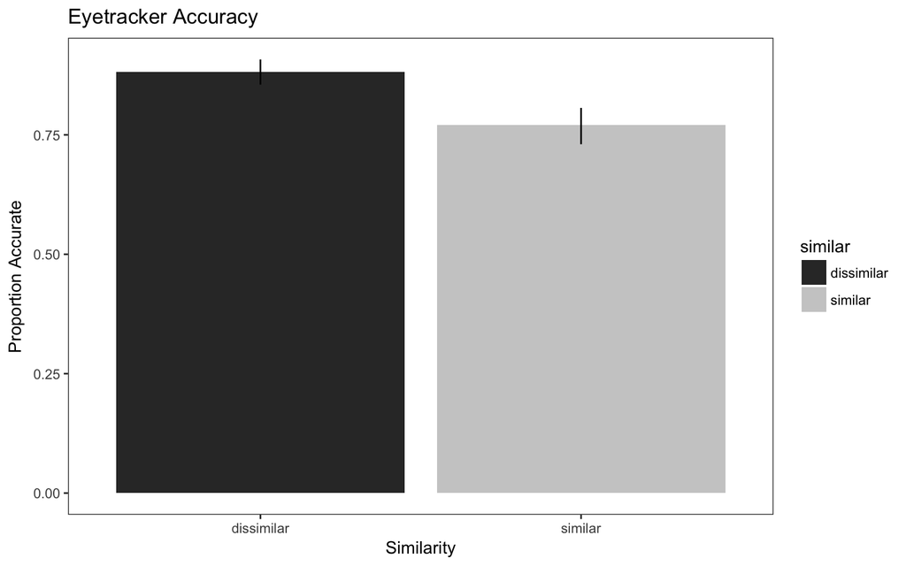

## 3.2 Switches

Set up a dataframe with switches averaged by accuracy and similiarity within participants.

```r
mss_et_acc <-  d_et_filt

mss_et_acc$acc <- str_replace(mss_et_acc$acc, "0", "inacc")
mss_et_acc$acc <- str_replace(mss_et_acc$acc, "1", "acc")

mss_et_inacc <-  mss_et_acc%>%
  group_by(ID, acc)%>%
  summarise(trans = mean(trans))%>%
  spread(acc, trans)%>%
  select(-acc)

mss_et_acc <-  mss_et_acc%>%
  group_by(ID, acc)%>%
  summarise(trans = mean(trans))%>%
  spread(acc, trans)

mss_et_sim <-  d_et_filt %>%
  dplyr::group_by(ID, acc, similar)%>%
  dplyr::summarise(trans = mean(trans))%>%
  dplyr::filter(acc == 1)%>%
  tidyr::spread(similar, trans)%>%
  dplyr::mutate(similar_acc = similar)%>%
  dplyr::mutate(dissimilar_acc = dissimilar)

mss_et_aov <- mss_et_inacc %>%
  left_join(mss_et_sim)%>%
  dplyr::filter(!is.na(similar_acc),
         !is.na(dissimilar_acc),
         !is.na(inacc))%>%
  gather("trial_type", "trans", inacc:dissimilar_acc) %>%
  filter(trial_type != "acc",
         trial_type != "similar",
         trial_type != "dissimilar")
```

### 3.2.1 Repeated measures ANOVA

Repeated-measures ANOVA with trial type (similar and accurate, dissimilar and accurate, and inaccurate) as the independent variable.

```r
ET.aov <- with(mss_et_aov,
                   aov(trans ~ trial_type +
                       Error(ID /trial_type))) #add error term for ID for repeated measures
summary(ET.aov)
```

```
##
## Error: ID
##           Df Sum Sq Mean Sq F value Pr(>F)
## Residuals 64  79.58   1.243
##
## Error: ID:trial_type
##             Df Sum Sq Mean Sq F value Pr(>F)
## trial_type   2   3.65  1.8258   3.512 0.0328 *
## Residuals  128  66.55  0.5199
## ---
## Signif. codes:  0 '***' 0.001 '**' 0.01 '*' 0.05 '.' 0.1 ' ' 1
```

```r
ezANOVA(
mss_et_aov
, trans
, ID
, within = trial_type
, within_full = NULL
, within_covariates = NULL
, between = NULL
, between_covariates = NULL
, observed = NULL
, diff = NULL
, reverse_diff = FALSE
, type = 2
, white.adjust = FALSE
, detailed = FALSE
, return_aov = FALSE
)
```

```
## $ANOVA
##       Effect DFn DFd        F          p p<.05        ges
## 2 trial_type   2 128 3.511755 0.03275193     * 0.02438034
##
## $`Mauchly's Test for Sphericity`
##       Effect         W            p p<.05
## 2 trial_type 0.6769412 4.595743e-06     *
##
## $`Sphericity Corrections`
##       Effect       GGe      p[GG] p[GG]<.05       HFe      p[HF] p[HF]<.05
## 2 trial_type 0.7558243 0.04612615         * 0.7702009 0.04520861         *
```

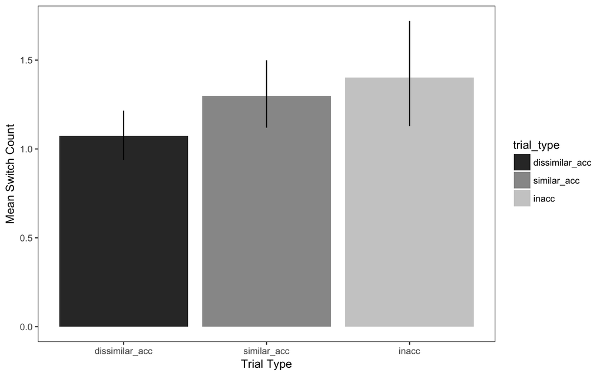

### 3.2.2 T-tests

```r
t.test(subset(mss_et_aov, trial_type=="inacc")$trans,
       subset(mss_et_aov, trial_type=="similar_acc")$trans, paired = TRUE)
```

```
##
##  Paired t-test
##
## data:  subset(mss_et_aov, trial_type == "inacc")$trans and subset(mss_et_aov, trial_type == "similar_acc")$trans
## t = 0.72147, df = 64, p-value = 0.4732
## alternative hypothesis: true difference in means is not equal to 0
## 95 percent confidence interval:
##  -0.1867799  0.3979520
## sample estimates:
## mean of the differences
##               0.1055861
```

```r
t.test(subset(mss_et_aov, trial_type=="inacc")$trans,
       subset(mss_et_aov, trial_type=="dissimilar_acc")$trans, paired = TRUE)
```

```
##
##  Paired t-test
##
## data:  subset(mss_et_aov, trial_type == "inacc")$trans and subset(mss_et_aov, trial_type == "dissimilar_acc")$trans
## t = 2.3445, df = 64, p-value = 0.02217
## alternative hypothesis: true difference in means is not equal to 0
## 95 percent confidence interval:
##  0.04856049 0.60804513
## sample estimates:
## mean of the differences
##               0.3283028
```

```r
t.test(subset(mss_et_aov, trial_type=="similar_acc")$trans,
       subset(mss_et_aov, trial_type=="dissimilar_acc")$trans, paired = TRUE)
```

```
##
##  Paired t-test
##
## data:  subset(mss_et_aov, trial_type == "similar_acc")$trans and subset(mss_et_aov, trial_type == "dissimilar_acc")$trans
## t = 2.6687, df = 64, p-value = 0.009638
## alternative hypothesis: true difference in means is not equal to 0
## 95 percent confidence interval:
##  0.05599471 0.38943875
## sample estimates:
## mean of the differences
##               0.2227167
```

```r
inacc_et <- psych::describe(subset(mss_et_aov, trial_type=="inacc")$trans)
sim_acc_et <- psych::describe(subset(mss_et_aov, trial_type=="similar_acc")$trans)
dissim_acc_et <- psych::describe(subset(mss_et_aov, trial_type=="dissimilar_acc")$trans)

cohensd_inacc_sim_acc_et <- abs((inacc_et$mean - sim_acc_et$mean)/((inacc_et$sd + sim_acc_et$sd)/2))
cohensd_inacc_sim_acc_et
```

```
## [1] 0.109122
```

```r
cohensd_inacc_dissim_acc_et <- abs((inacc_et$mean - dissim_acc_et$mean)/((inacc_et$sd + dissim_acc_et$sd)/2))
cohensd_inacc_dissim_acc_et
```

```
## [1] 0.3773727
```

```r
cohensd_sim_acc_dissim_acc_et <- abs((sim_acc_et$mean - dissim_acc_et$mean)/((sim_acc_et$sd + dissim_acc_et$sd)/2))
cohensd_sim_acc_dissim_acc_et
```

```
## [1] 0.3282982
```

## 3.3 Summary of Eyetracker Results

Accuracy was higher for dissimilar items.

Repeated-measures ANOVA shows that there is a difference between means for similar-accurate, dissimilar-accurate, and inaccurate.

T-test summary:

inaccurate - similar-accurate

inaccurate - dissimilar-accurate*

similar-accurate - dissimilar-accurate**

# 4 Touchscreen task

filter fast and slow RTs, missing data, unfamiliar trials, and kids who performed below chance. Two participants dropped for chance performance (70 and 89).

```r
top_bound <- mean(log(d_ts$RT)) + 3*sd(log(d_ts$RT))
bottom_bound <- mean(log(d_ts$RT)) - 3*sd(log(d_ts$RT))

d_filt_rt <- d_ts %>%
  dplyr::filter(log(RT) < top_bound,
         log(RT) > bottom_bound,
         !is.na(acc),
         familiarity != 0)

mss_ts_acc <-  d_filt_rt
mss_ts_acc$acc <- as.numeric(as.character(mss_ts_acc$acc))
mss_ts_acc <- mss_ts_acc %>%
  group_by(ID)%>%
  summarise(acc = mean(acc))%>%
  mutate(drop_acc = acc < .5)

drop_acc_ts <- mss_ts_acc$ID[mss_ts_acc$drop_acc == TRUE]

d_filt_rt <- d_filt_rt %>%
  dplyr::filter(!ID %in% drop_acc_ts)

d_filt_rt_log <- d_filt_rt %>%
  mutate(RT = log(RT))%>%
  dplyr::filter(!ID %in% drop_acc_ts)
```

Create a dataset that does NOT drop based on extreme RTs.

```r
d_incl_rt <- d_ts %>%
  dplyr::filter(!is.na(acc),
         familiarity != 0)

mss_ts_acc_in <-  d_incl_rt
mss_ts_acc_in$acc <- as.numeric(as.character(mss_ts_acc_in$acc))
mss_ts_acc_in <- mss_ts_acc_in %>%
  group_by(ID)%>%
  summarise(acc = mean(acc))%>%
  mutate(drop_acc = acc < .5)

drop_acc <- mss_ts_acc_in$ID[mss_ts_acc_in$drop_acc == TRUE]

d_incl_rt_log <- d_incl_rt %>%
  mutate(RT = log(RT))
```

## 4.1 Accuracy

Get a dataframe for looking at accuracy by similarity.

```r
mss_ts_acc_t <-  d_filt_rt%>%
  group_by(ID, similar)

mss_ts_acc_t$acc <- as.numeric(as.character(mss_ts_acc_t$acc))

mss_ts_acc_t <- mss_ts_acc_t %>%
  summarise(acc = mean(acc))%>%
  spread(similar, acc)
```

Same without exclusions for extreme RTs.

```r
mss_ts_acc_t_i <-  d_incl_rt%>%
  group_by(ID, similar)

mss_ts_acc_t_i$acc <- as.numeric(as.character(mss_ts_acc_t_i$acc))

mss_ts_acc_t_i <- mss_ts_acc_t_i %>%
  summarise(acc = mean(acc))%>%
  spread(similar, acc)
```

T-test for effect of similarity on accuracy.

```r
t.test(mss_ts_acc_t$similar,
       mss_ts_acc_t$dissimilar, paired = TRUE)
```

```
##
##  Paired t-test
##
## data:  mss_ts_acc_t$similar and mss_ts_acc_t$dissimilar
## t = -7.2399, df = 70, p-value = 4.553e-10
## alternative hypothesis: true difference in means is not equal to 0
## 95 percent confidence interval:
##  -0.17344259 -0.09852254
## sample estimates:
## mean of the differences
##              -0.1359826
```

```r
similar <- psych::describe(mss_ts_acc_t$similar)
dissimilar <- psych::describe(mss_ts_acc_t$dissimilar)

similar
```

```
##    vars  n mean   sd median trimmed  mad min max range  skew kurtosis   se
## X1    1 71 0.71 0.17    0.7    0.72 0.21 0.4 0.9   0.5 -0.42    -1.14 0.02
```

```r
dissimilar
```

```
##    vars  n mean   sd median trimmed  mad  min max range  skew kurtosis
## X1    1 71 0.85 0.14   0.89    0.86 0.16 0.43   1  0.57 -0.73    -0.21
##      se
## X1 0.02
```

```r
cohensd_acc <- abs((similar$mean - dissimilar$mean)/((similar$sd + dissimilar$sd)/2))
cohensd_acc
```

```
## [1] 0.8901871
```

Same without exclusions.

```r
t.test(mss_ts_acc_t_i$similar,
       mss_ts_acc_t_i$dissimilar, paired = TRUE)
```

```
##
##  Paired t-test
##
## data:  mss_ts_acc_t_i$similar and mss_ts_acc_t_i$dissimilar
## t = -7.7506, df = 72, p-value = 4.475e-11
## alternative hypothesis: true difference in means is not equal to 0
## 95 percent confidence interval:
##  -0.1760668 -0.1040267
## sample estimates:
## mean of the differences
##              -0.1400467
```

```r
similar <- psych::describe(mss_ts_acc_t_i$similar)
dissimilar <- psych::describe(mss_ts_acc_t_i$dissimilar)

cohensd_acc <- abs((similar$mean - dissimilar$mean)/((similar$sd + dissimilar$sd)/2))
cohensd_acc
```

```
## [1] 0.8668093
```

Plot accuracy.

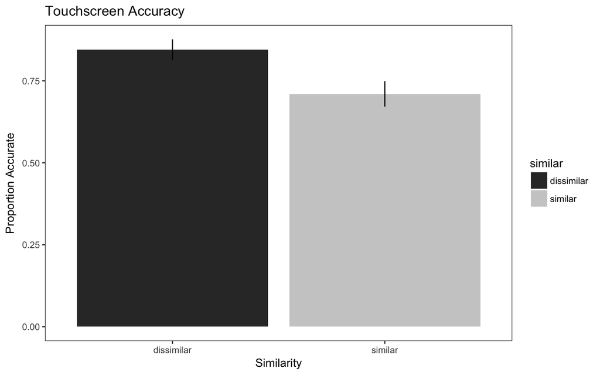

## 4.2 RTs

```r
mss_ts_acc <-  d_filt_rt

mss_ts_acc$acc <- str_replace(mss_ts_acc$acc, "0", "inacc")
mss_ts_acc$acc <- str_replace(mss_ts_acc$acc, "1", "acc")

mss_ts_inacc <-  mss_ts_acc%>%
  group_by(ID, acc)%>%
  summarise(RT = mean(RT))%>%
  spread(acc, RT)%>%
  select(-acc)

mss_ts_acc <-  mss_ts_acc%>%
  group_by(ID, acc)%>%
  summarise(RT = mean(RT))%>%
  spread(acc, RT)

mss_ts_sim <-  d_filt_rt %>%
  dplyr::group_by(ID, acc, similar)%>%
  dplyr::summarise(RT = mean(RT))%>%
  dplyr::filter(acc == 1)%>%
  tidyr::spread(similar, RT)%>%
  dplyr::mutate(similar_acc = similar)%>%
  dplyr::mutate(dissimilar_acc = dissimilar)

mss_ts_aov <- mss_ts_inacc %>%
  left_join(mss_ts_sim)%>%
  dplyr::filter(!is.na(similar_acc),
         !is.na(dissimilar_acc),
         !is.na(inacc))%>%
  gather("trial_type", "RT", inacc:dissimilar_acc) %>%
  filter(trial_type != "acc",
         trial_type != "similar",
         trial_type != "dissimilar")
```

Same without exclusions.

```r
mss_ts_acc_i <-  d_incl_rt

mss_ts_acc_i$acc <- str_replace(mss_ts_acc_i$acc, "0", "inacc")
mss_ts_acc_i$acc <- str_replace(mss_ts_acc_i$acc, "1", "acc")

mss_ts_inacc_i <-  mss_ts_acc_i%>%
  group_by(ID, acc)%>%
  summarise(RT = mean(RT))%>%
  spread(acc, RT)%>%
  select(-acc)

mss_ts_acc_i <-  mss_ts_acc_i%>%
  group_by(ID, acc)%>%
  summarise(RT = mean(RT))%>%
  spread(acc, RT)

mss_ts_sim_i <-  d_incl_rt %>%
  dplyr::group_by(ID, acc, similar)%>%
  dplyr::summarise(RT = mean(RT))%>%
  dplyr::filter(acc == 1)%>%
  tidyr::spread(similar, RT)%>%
  dplyr::mutate(similar_acc = similar)%>%
  dplyr::mutate(dissimilar_acc = dissimilar)

mss_ts_aov_i <- mss_ts_inacc_i %>%
  left_join(mss_ts_sim_i)%>%
  dplyr::filter(!is.na(similar_acc),
         !is.na(dissimilar_acc),
         !is.na(inacc))%>%
  gather("trial_type", "RT", inacc:dissimilar_acc) %>%
  filter(trial_type != "acc",
         trial_type != "similar",
         trial_type != "dissimilar")
```

### 4.2.1 Repeated-measures ANOVA

Repeated-measures ANOVA with trial type (similar and accurate, dissimilar and accurate, and inaccurate) as the independent variable.

```r
TS.aov <- with(mss_ts_aov,
                   aov(RT ~ trial_type +
                       Error(ID /trial_type))) #add error term for ID for repeated measures
summary(TS.aov)
```

```
##
## Error: ID
##           Df    Sum Sq Mean Sq F value Pr(>F)
## Residuals 70 422750725 6039296
##
## Error: ID:trial_type
##             Df    Sum Sq  Mean Sq F value   Pr(>F)
## trial_type   2  48726250 24363125   15.51 8.23e-07 ***
## Residuals  140 219899116  1570708
## ---
## Signif. codes:  0 '***' 0.001 '**' 0.01 '*' 0.05 '.' 0.1 ' ' 1
```

```r
ezANOVA(
mss_ts_aov
, RT
, ID
, within = trial_type
, within_full = NULL
, within_covariates = NULL
, between = NULL
, between_covariates = NULL
, observed = NULL
, diff = NULL
, reverse_diff = FALSE
, type = 2
, white.adjust = FALSE
, detailed = FALSE
, return_aov = FALSE
)
```

```
## $ANOVA
##       Effect DFn DFd        F            p p<.05       ges
## 2 trial_type   2 140 15.51092 8.229101e-07     * 0.0704772
##
## $`Mauchly's Test for Sphericity`
##       Effect         W            p p<.05
## 2 trial_type 0.7768571 0.0001647288     *
##
## $`Sphericity Corrections`
##       Effect      GGe        p[GG] p[GG]<.05       HFe        p[HF]
## 2 trial_type 0.817566 5.955393e-06         * 0.8344517 4.956545e-06
##   p[HF]<.05
## 2         *
```

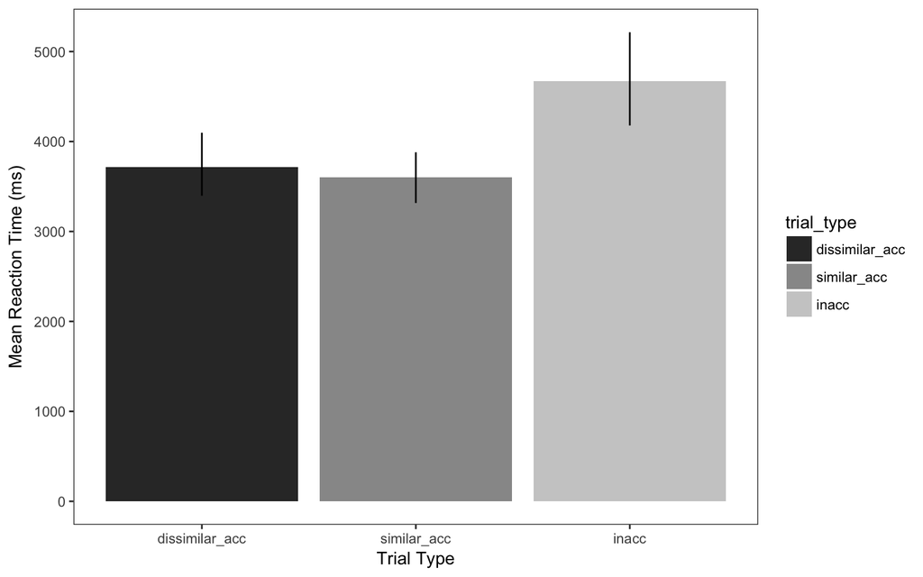

same without exclusions

```r
TS.aov_i <- with(mss_ts_aov_i,
                   aov(RT ~ trial_type +
                       Error(ID /trial_type))) #add error term for ID for repeated measures
summary(TS.aov_i)
```

```
##
## Error: ID
##           Df    Sum Sq  Mean Sq F value Pr(>F)
## Residuals 72 722791004 10038764
##
## Error: ID:trial_type
##             Df    Sum Sq  Mean Sq F value   Pr(>F)
## trial_type   2  50893674 25446837   7.276 0.000977 ***
## Residuals  144 503625567  3497400
## ---
## Signif. codes:  0 '***' 0.001 '**' 0.01 '*' 0.05 '.' 0.1 ' ' 1
```

```r
ezANOVA(
mss_ts_aov_i
, RT
, ID
, within = trial_type
, within_full = NULL
, within_covariates = NULL
, between = NULL
, between_covariates = NULL
, observed = NULL
, diff = NULL
, reverse_diff = FALSE
, type = 2
, white.adjust = FALSE
, detailed = FALSE
, return_aov = FALSE
)
```

```
## $ANOVA
##       Effect DFn DFd       F            p p<.05        ges
## 2 trial_type   2 144 7.27593 0.0009767036     * 0.03984441
##
## $`Mauchly's Test for Sphericity`
##       Effect         W        p p<.05
## 2 trial_type 0.9931336 0.783018
##
## $`Sphericity Corrections`
##       Effect       GGe       p[GG] p[GG]<.05      HFe        p[HF]
## 2 trial_type 0.9931804 0.001006033         * 1.021261 0.0009767036
##   p[HF]<.05
## 2         *
```

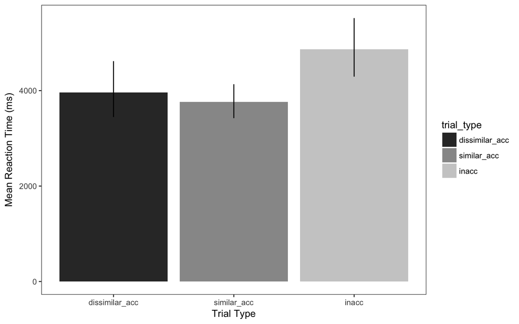

### 4.2.2 T-tests

```r
t.test(subset(mss_ts_aov, trial_type=="inacc")$RT,
       subset(mss_ts_aov, trial_type=="similar_acc")$RT, paired = TRUE)
```

```
##
##  Paired t-test
##
## data:  subset(mss_ts_aov, trial_type == "inacc")$RT and subset(mss_ts_aov, trial_type == "similar_acc")$RT
## t = 4.8049, df = 70, p-value = 8.533e-06
## alternative hypothesis: true difference in means is not equal to 0
## 95 percent confidence interval:
##   623.6552 1508.7915
## sample estimates:
## mean of the differences
##                1066.223
```

```r
t.test(subset(mss_ts_aov, trial_type=="inacc")$RT,
       subset(mss_ts_aov, trial_type=="dissimilar_acc")$RT, paired = TRUE)
```

```
##
##  Paired t-test
##
## data:  subset(mss_ts_aov, trial_type == "inacc")$RT and subset(mss_ts_aov, trial_type == "dissimilar_acc")$RT
## t = 3.9151, df = 70, p-value = 0.0002073
## alternative hypothesis: true difference in means is not equal to 0
## 95 percent confidence interval:
##   467.8172 1439.3666
## sample estimates:
## mean of the differences
##                953.5919
```

```r
t.test(subset(mss_ts_aov, trial_type=="similar_acc")$RT,
       subset(mss_ts_aov, trial_type=="dissimilar_acc")$RT, paired = TRUE)
```

```
##
##  Paired t-test
##
## data:  subset(mss_ts_aov, trial_type == "similar_acc")$RT and subset(mss_ts_aov, trial_type == "dissimilar_acc")$RT
## t = -0.72444, df = 70, p-value = 0.4712
## alternative hypothesis: true difference in means is not equal to 0
## 95 percent confidence interval:
##  -422.7128  197.4499
## sample estimates:
## mean of the differences
##               -112.6314
```

```r
inacc_ts <- psych::describe(subset(mss_ts_aov, trial_type=="inacc")$RT)
sim_acc_ts <- psych::describe(subset(mss_ts_aov, trial_type=="similar_acc")$RT)
dissim_acc_ts <- psych::describe(subset(mss_ts_aov, trial_type=="dissimilar_acc")$RT)

cohensd_inacc_sim_acc_ts <- abs((inacc_ts$mean - sim_acc_ts$mean)/((inacc_ts$sd + sim_acc_ts$sd)/2))
cohensd_inacc_sim_acc_ts
```

```
## [1] 0.6038735
```

```r
cohensd_inacc_dissim_acc_ts <- abs((inacc_ts$mean - dissim_acc_ts$mean)/((inacc_ts$sd + dissim_acc_ts$sd)/2))
cohensd_inacc_dissim_acc_ts
```

```
## [1] 0.4957435
```

```r
cohensd_sim_acc_dissim_acc_ts <- abs((sim_acc_ts$mean - dissim_acc_ts$mean)/((sim_acc_ts$sd + dissim_acc_ts$sd)/2))
cohensd_sim_acc_dissim_acc_ts
```

```
## [1] 0.08233141
```

Same without exclusions.

```r
t.test(subset(mss_ts_aov_i, trial_type=="inacc")$RT,
       subset(mss_ts_aov_i, trial_type=="similar_acc")$RT, paired = TRUE)
```

```
##
##  Paired t-test
##
## data:  subset(mss_ts_aov_i, trial_type == "inacc")$RT and subset(mss_ts_aov_i, trial_type == "similar_acc")$RT
## t = 3.4983, df = 72, p-value = 0.0008069
## alternative hypothesis: true difference in means is not equal to 0
## 95 percent confidence interval:
##   476.0061 1737.1780
## sample estimates:
## mean of the differences
##                1106.592
```

```r
t.test(subset(mss_ts_aov_i, trial_type=="inacc")$RT,
       subset(mss_ts_aov_i, trial_type=="dissimilar_acc")$RT, paired = TRUE)
```

```
##
##  Paired t-test
##
## data:  subset(mss_ts_aov_i, trial_type == "inacc")$RT and subset(mss_ts_aov_i, trial_type == "dissimilar_acc")$RT
## t = 3.0701, df = 72, p-value = 0.003017
## alternative hypothesis: true difference in means is not equal to 0
## 95 percent confidence interval:
##   319.1863 1501.1312
## sample estimates:
## mean of the differences
##                910.1587
```

```r
t.test(subset(mss_ts_aov_i, trial_type=="similar_acc")$RT,
       subset(mss_ts_aov_i, trial_type=="dissimilar_acc")$RT, paired = TRUE)
```

```
##
##  Paired t-test
##
## data:  subset(mss_ts_aov_i, trial_type == "similar_acc")$RT and subset(mss_ts_aov_i, trial_type == "dissimilar_acc")$RT
## t = -0.62271, df = 72, p-value = 0.5354
## alternative hypothesis: true difference in means is not equal to 0
## 95 percent confidence interval:
##  -825.2730  432.4065
## sample estimates:
## mean of the differences
##               -196.4333
```

## 4.3 Summary of Touchscreen Results

Accuracy was higher for dissimilar items.

Repeated-measures ANOVA shows that there is a difference between means for similar-accurate, dissimilar-accurate, and inaccurate.

T-test summary:

inaccurate - similar-accurate**

inaccurate - dissimilar-accurate**

similar-accurate - dissimilar-accurate

# 5 Accuracy across tasks for plot

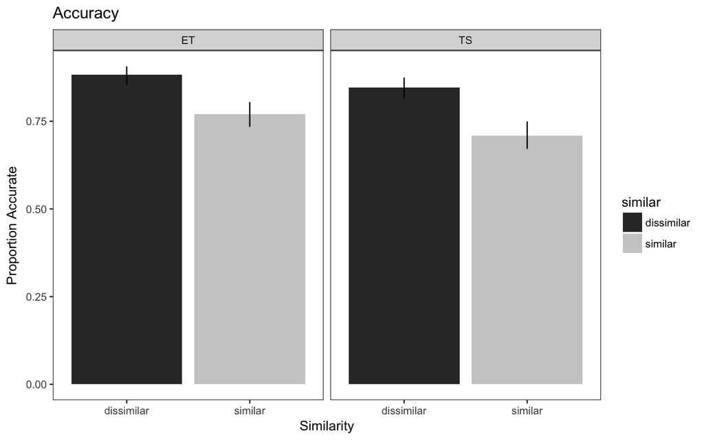

# 6 Any effect of age?

```r
et <- spread(mss_et_aov, trial_type, trans)%>%
  mutate(dacc_inacc = dissimilar_acc - inacc,
         sacc_inacc = similar_acc - inacc,
         dacc_sacc = dissimilar_acc - similar_acc)%>%
  left_join(demo)

ts <- spread(mss_ts_aov, trial_type, RT)%>%
  mutate(dacc_inacc = dissimilar_acc - inacc,
         sacc_inacc = similar_acc - inacc,
         dacc_sacc = dissimilar_acc - similar_acc)%>%
  left_join(demo)

rcorr(et$age_months, et$dacc_inacc)
```

```
##       x     y
## x  1.00 -0.07
## y -0.07  1.00
##
## n= 65
##
##
## P
##   x      y
## x        0.5636
## y 0.5636
```

```r
rcorr(et$age_months, et$sacc_inacc)
```

```
##       x     y
## x  1.00 -0.03
## y -0.03  1.00
##
## n= 65
##
##
## P
##   x      y
## x        0.8378
## y 0.8378
```

```r
rcorr(et$age_months, et$dacc_sacc)
```

```
##       x     y
## x  1.00 -0.08
## y -0.08  1.00
##
## n= 65
##
##
## P
##   x      y
## x        0.5419
## y 0.5419
```

```r
rcorr(ts$age_months, ts$dacc_inacc)
```

```
##     x   y
## x 1.0 0.1
## y 0.1 1.0
##
## n= 71
##
##
## P
##   x      y
## x        0.3913
## y 0.3913
```

```r
rcorr(ts$age_months, ts$sacc_inacc)
```

```
##      x    y
## x 1.00 0.12
## y 0.12 1.00
##
## n= 71
##
##
## P
##   x      y
## x        0.3101
## y 0.3101
```

```r
rcorr(ts$age_months, ts$dacc_sacc)
```

```
##       x     y
## x  1.00 -0.01
## y -0.01  1.00
##
## n= 71
##
##
## P
##   x      y
## x        0.9173
## y 0.9173
```